# Manager Gender and Technology Adoption in Peruvian Firms, 2010–2023

Econometric Analysis of Firm Data (KAN-CEAPV2505U) — full analysis notebook

# 1 Overview

**Research question.** Are firms with a female top manager less likely to adopt technology — measured by having their **own website** and an **internationally recognised quality certification** — once unobserved, time-constant firm differences are taken into account? And how did the gap evolve across the three survey waves, including the wave after the COVID-19 pandemic?

**Data.** World Bank Enterprise Surveys for Peru, three waves (2010, 2017, 2023) linked into an **unbalanced panel**.

**Methods, in the order of the paper.**

1. Pooled OLS linear probability model (LPM) as the baseline, with a short probit check of the functional form.
2. Panel estimators on the unbalanced panel: pooled OLS, random effects (RE) and fixed effects (FE).
3. The Mundlak (correlated random effects) test of RE against FE.
4. Tests for sample selection (attrition) in unbalanced panels, following the course lecture on unbalanced panels.

The notebook writes every table and figure used in the paper to `tables/` and `figures/`.

**Required files (not distributed in the repository, see README):** download from the World Bank Enterprise Surveys portal and place in `data/`:

- `Peru_2006_2010_2017.dta` — Peru Enterprise Survey 2006–2017, panel data (Ref. PER_2006-2017_ES-P_v01_M)
- `Peru_2017_2023.dta` — Peru 2017–2023 panel file (contains the Peru WBES 2023, Ref. PER_2023_WBES_v01_M)

```r
library(haven)            # read Stata files
library(dplyr)            # data handling
library(plm)              # panel estimators (pooled OLS, FE, RE)
library(sandwich)         # robust and clustered covariance matrices
library(lmtest)           # coeftest, bptest
library(ggplot2)          # figure
dir.create("tables", showWarnings = FALSE)
dir.create("figures", showWarnings = FALSE)
```

# 2 Data construction

## 2.1 Recoding rules

In the Enterprise Surveys, yes/no questions are coded 1 = yes, 2 = no, and negative values are non-responses (−9 don’t know, −7 refused, −6 not applicable). Non-responses are set to missing.

```r
yesno <- function(x) { x <- as.numeric(x); ifelse(x == 1, 1, ifelse(x == 2, 0, NA)) }
nonneg <- function(x) { x <- as.numeric(x); ifelse(x < 0, NA, x) }
```

## 2.2 Linking the two panel files

The 2006–2017 panel file contains the 2010 wave; the 2017–2023 panel file contains the 2017 and 2023 waves. Both files contain the **same 2017 survey**, and every 2017 firm has the same identifier (`idstd`) in both files. The 2017 `idstd` therefore links firms across all three waves:

- firms observed in 2017 get the key `S<idstd2017>` in both files;
- firms observed only in 2010 (old file) or only in 2023 (new file) get a file-specific key.

This rule can only link firms through the 2017 wave: a firm interviewed in 2010 and 2023 but not 2017 would get two different keys. Whether such firms exist is checked against the World Bank’s own panel indicator (`panel`) in the 2017–2023 file, which classifies every 2023 firm as “2023 only” (fresh sample), “2017 and 2023” or “2023 with panelid but can not be matched”. The 2023 panel component was drawn from the 2017 sample, so no 2023 firm is recorded as an earlier (2010) panel firm, and the files contain no identifier that would link 2010 to 2023 directly.

```r
old <- read_dta("data/Peru_2006_2010_2017.dta")
new <- read_dta("data/Peru_2017_2023.dta")

# key for the 2017-2023 file
new <- new %>%
  group_by(panelid) %>%
  mutate(id17 = ifelse(any(year == 2017), idstd[year == 2017][1], NA)) %>%
  ungroup() %>%
  mutate(key = ifelse(!is.na(id17), paste0("S", id17), paste0("N", panelid)))

# key for the 2010 wave of the 2006-2017 file
old <- old %>%
  group_by(panelid) %>%
  mutate(id17 = ifelse(any(year == 2017), idstd[year == 2017][1], NA)) %>%
  ungroup() %>%
  mutate(key = ifelse(!is.na(id17), paste0("S", id17), paste0("O", panelid)))

# check: the 2017 identifiers are the same set in both files
stopifnot(setequal(old$idstd[old$year == 2017], new$idstd[new$year == 2017]))

# World Bank panel status of the 2023 firms: only fresh firms (2) or 2017 panel firms (3)
print(table(year = new$year, panel = as_factor(new$panel)))
```

```
      panel
year   2017 only 2023 only 2017 and 2023
  2017       645         0           358
  2023         0       629           358
      panel
year   2023 with panelid but can not be matched
  2017                                        0
  2023                                        0
```

```r
stopifnot(all(new$panel[new$year == 2023] %in% c(2, 3)))
```

## 2.3 Harmonising the variables

Sector is coded differently in 2010, so I use three broad sectors that can be built consistently: manufacturing, retail and other services (2010: ISIC Rev. 3 two-digit code `a4b`; 2017/2023: harmonised sampling sector `a4a`).

```r
# validate the raw sector and region codes before classifying them (no negative or unexpected codes)
print(table(old$a4b[old$year == 2010], useNA = "ifany"))
```

```
 15  17  18  19  20  21  22  24  25  26  27  28  29  31  33  34  36  37  45  50
162  52 113  23   1   9  25 111  42  20  13 125  25  14   2   8  14   1   2  11
 51  52  55  60  72
 59 104  24  33   7
```

```r
print(table(new$year, new$a4a, useNA = "ifany"))
```

```
         1   2   3   4   5   6   7
  2017 174  63  94 231 175  33 233
  2023 109  44  68 227 160  89 290
```

```r
print(table(c(old$a2[old$year == 2010], new$a2), useNA = "ifany"))
```

```
   1    2    3    4    5
1678  471  310  383  148
```

```r
stopifnot(all(old$a4b[old$year == 2010] %in% c(15:37, 45, 50:52, 55, 60, 72)),
          all(new$a4a %in% 1:7), all(c(old$a2[old$year == 2010], new$a2) %in% 1:5))

w10 <- old %>% filter(year == 2010) %>%
  transmute(key, year = 2010,
            female   = yesno(`_2010_2017_b7a`),
            website  = yesno(c22b),
            cert     = yesno(b8),
            l1 = nonneg(l1), mgr_exp = nonneg(b7), d3c = nonneg(d3c), b2b = nonneg(b2b),
            multi    = yesno(a7),
            region   = as.numeric(a2),
            sector   = case_when(a4b >= 15 & a4b <= 37 ~ "Manufacturing",
                                 a4b == 52 ~ "Retail", TRUE ~ "Other services"))

w1723 <- new %>%
  transmute(key, year = as.numeric(year),
            female   = yesno(b7a),
            website  = yesno(c22b),
            cert     = yesno(b8),
            l1 = nonneg(l1), mgr_exp = nonneg(b7), d3c = nonneg(d3c), b2b = nonneg(b2b),
            multi    = yesno(a7),
            region   = as.numeric(a2),
            sector   = case_when(a4a %in% 1:4 ~ "Manufacturing",
                                 a4a == 5 ~ "Retail", TRUE ~ "Other services"))

df <- bind_rows(w10, w1723) %>%
  mutate(ln_emp    = ifelse(l1 > 0, log(l1), NA),
         exporter  = as.numeric(d3c >= 10),
         foreign   = as.numeric(b2b >= 10),
         y2017     = as.numeric(year == 2017),
         y2023     = as.numeric(year == 2023),
         female_x23 = female * y2023,
         sector    = factor(sector, levels = c("Manufacturing", "Retail", "Other services")),
         region    = factor(region)) %>%
  arrange(key, year)

stopifnot(!any(duplicated(df[c("key", "year")])))
cat("Observations:", nrow(df), " Firms:", n_distinct(df$key), "\n")
```

```
Observations: 2990  Firms: 2258
```

```r
table(df$year)
```

```
2010 2017 2023
1000 1003  987
```

**Why “part of a larger firm” is not a control.** The share of firms reporting that they belong to a larger firm drops from about 20–25% in 2010 and 2017 to about 1% in 2023 (see the descriptive table). Such a drop is implausible as a real change and points to a change in the questionnaire. Inside FE it would create artificial within-firm changes, so the variable is reported descriptively but not used as a control.

**Why firm age is not a control.** Age equals the survey year minus the founding year. With year dummies, the founding year is time-constant and is absorbed by the firm effect, so age cannot be separated from the year and firm effects in the FE model. To compare pooled OLS, RE and FE on the same specification, age is left out of all models.

## 2.4 Panel structure

```r
pattern <- df %>% group_by(key) %>%
  summarise(waves = paste(sort(year), collapse = "-"), T_i = n(), .groups = "drop")
pattern %>% count(waves, name = "firms") %>% arrange(desc(firms))
```

| waves | firms |
| --- | --- |
| 2023 | 629 |
| 2010 | 626 |
| 2017 | 414 |
| 2010-2017 | 231 |
| 2017-2023 | 215 |
| 2010-2017-2023 | 143 |

```r
cat("Firms observed in at least two waves:", sum(pattern$T_i >= 2), "\n")
```

```
Firms observed in at least two waves: 589
```

```r
switchers <- df %>% filter(!is.na(female)) %>% group_by(key) %>%
  summarise(n = n(), sw = n_distinct(female) > 1, .groups = "drop")
cat("Of these, firms whose manager gender changes:", sum(switchers$sw), "\n")
```

```
Of these, firms whose manager gender changes: 64
```

```r
# sector and region recorded differently for the same firm in different waves
multi <- df %>% group_by(key) %>% filter(n() >= 2)
cat("Multi-wave firms whose recorded sector changes:", multi %>% summarise(s = n_distinct(sector) > 1) %>% pull(s) %>% sum(),
    "| region changes:", multi %>% summarise(s = n_distinct(region) > 1) %>% pull(s) %>% sum(), "\n")
```

```
Multi-wave firms whose recorded sector changes: 41 | region changes: 4
```

# 3 Descriptive statistics

```r
desc_vars <- c(website = "Own website", cert = "Quality certification",
               l1 = "Employees (permanent full-time)", mgr_exp = "Manager experience (years)",
               exporter = "Exporter ($\\geq$10\\% of sales)", foreign = "Foreign owned ($\\geq$10\\%)",
               multi = "Part of larger firm")
desc <- df %>% filter(!is.na(female)) %>%
  mutate(manuf = as.numeric(sector == "Manufacturing"), retail = as.numeric(sector == "Retail")) %>%
  group_by(year, female) %>%
  summarise(across(c(names(desc_vars), manuf, retail), ~ mean(.x, na.rm = TRUE)), n = n(), .groups = "drop")
desc
```

| year | female | website | cert | l1 | mgr_exp | exporter | foreign | multi | manuf | retail | n |
| --- | --- | --- | --- | --- | --- | --- | --- | --- | --- | --- | --- |
| 2010 | 0 | 0.6784091 | 0.2616487 | 195.26591 | 22.20046 | 0.2295455 | 0.1251422 | 0.2034091 | 0.7590909 | 0.1022727 | 880 |
| 2010 | 1 | 0.5294118 | 0.2017544 | 128.56303 | 22.36752 | 0.2352941 | 0.0672269 | 0.1596639 | 0.7647059 | 0.1176471 | 119 |
| 2017 | 0 | 0.6916462 | 0.2244143 | 172.16953 | 24.63490 | 0.1727941 | 0.0992647 | 0.2475490 | 0.5637255 | 0.1666667 | 816 |
| 2017 | 1 | 0.5989305 | 0.1092896 | 95.18280 | 22.84946 | 0.1550802 | 0.0481283 | 0.1711230 | 0.5454545 | 0.2085561 | 187 |
| 2023 | 0 | 0.7966321 | 0.2254642 | 104.03497 | 23.79373 | 0.1450777 | 0.0922078 | 0.0116580 | 0.4727979 | 0.1450777 | 772 |
| 2023 | 1 | 0.7570093 | 0.1268293 | 95.55349 | 21.93458 | 0.1209302 | 0.0744186 | 0.0000000 | 0.3860465 | 0.2232558 | 215 |

```r
# raw female-male gaps with Welch t-tests, by wave
for (v in c("website", "cert")) for (t in c(2010, 2017, 2023)) {
  d <- df %>% filter(year == t, !is.na(female), !is.na(.data[[v]]))
  tt <- t.test(d[[v]][d$female == 1], d[[v]][d$female == 0])
  cat(sprintf("%-8s %d  gap (F-M) = %6.3f   p = %.3f\n", v, t, diff(rev(tt$estimate)), tt$p.value))
}
```

```
website  2010  gap (F-M) = -0.149   p = 0.003
website  2017  gap (F-M) = -0.093   p = 0.019
website  2023  gap (F-M) = -0.040   p = 0.227
cert     2010  gap (F-M) = -0.060   p = 0.143
cert     2017  gap (F-M) = -0.115   p = 0.000
cert     2023  gap (F-M) = -0.099   p = 0.000
```

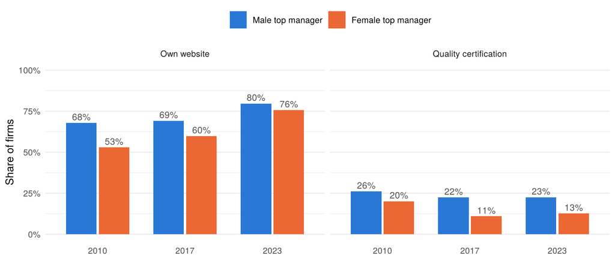

```r
fig <- df %>% filter(!is.na(female)) %>%
  tidyr::pivot_longer(c(website, cert), names_to = "outcome", values_to = "y") %>%
  filter(!is.na(y)) %>%
  group_by(outcome, year, female) %>% summarise(share = mean(y), .groups = "drop") %>%
  mutate(outcome = recode(outcome, website = "Own website", cert = "Quality certification"),
         Manager = factor(ifelse(female == 1, "Female top manager", "Male top manager"),
                          levels = c("Male top manager", "Female top manager")))
p <- ggplot(fig, aes(factor(year), share, fill = Manager)) +
  geom_col(position = position_dodge(width = 0.75), width = 0.7) +
  geom_text(aes(label = scales::percent(share, accuracy = 1)),
            position = position_dodge(width = 0.75), vjust = -0.4, size = 3, colour = "#52514e") +
  facet_wrap(~ outcome) +
  scale_fill_manual(values = c("Male top manager" = "#2a78d6", "Female top manager" = "#eb6834")) +
  scale_y_continuous(labels = scales::percent, limits = c(0, 1)) +
  labs(x = NULL, y = "Share of firms", fill = NULL) +
  theme_minimal(base_size = 10) +
  theme(legend.position = "top", panel.grid.major.x = element_blank())
p
```

```r
ggsave("figures/fig1_outcomes.pdf", p, width = 8, height = 3.4)
```

# 4 Pooled OLS: the linear probability model

## 4.1 Model

For outcome $y_{it}\in\{0,1\}$ of firm $i$ in wave $t$:

$$y_{it} = \beta_0 + \beta_1 F_{it} + \beta_3 (F_{it}\times D^{2023}_t) +
\delta_1 D^{2017}_t + \delta_2 D^{2023}_t + \mathbf
x_{it}'\boldsymbol\gamma + v_{it}$$

$E(y\mid\mathbf x) = P(y=1\mid\mathbf x)$, so coefficients are changes in probability. $\beta_1$ is the female–male gap before the pandemic (2010 and 2017), $\beta_1+\beta_3$ the gap in 2023, and $\beta_3$ the change in the gap.

Pooled OLS treats the composite error $v_{it} = a_i + u_{it}$ as one error. It is consistent only if $a_i$ is uncorrelated with the regressors, and the errors of the same firm are correlated over time, so standard errors are **clustered by firm**. The LPM error is heteroskedastic by construction ($\text{Var}(v\mid\mathbf x) = p(\mathbf x)[1-p(\mathbf x)]$), which clustering also handles.

```r
ctrl_tv <- c("ln_emp", "mgr_exp", "exporter", "foreign")      # time-varying controls (see note on "multi" above)
rhs     <- paste(c("female", "female_x23", "y2017", "y2023", ctrl_tv), collapse = " + ")
rhs_tc  <- paste(rhs, "+ sector + region")                               # + time-constant controls

est_sample <- function(v) df %>% filter(if_all(all_of(c(v, "female", ctrl_tv, "sector", "region")), ~ !is.na(.x)))
pdat <- function(v) pdata.frame(as.data.frame(est_sample(v)), index = c("key", "year"))

cl_vcov <- function(m) vcovHC(m, method = "arellano", type = "HC1", cluster = "group")

pols <- list(); for (v in c("website", "cert")) {
  pols[[v]] <- plm(as.formula(paste(v, "~", rhs_tc)), data = pdat(v), model = "pooling")
  cat("\n====", v, "====\n"); print(coeftest(pols[[v]], vcov = cl_vcov(pols[[v]]))[c("female", "female_x23"), ])
}
```

```
==== website ====
              Estimate Std. Error   t value   Pr(>|t|)
female     -0.06094720 0.02939581 -2.073330 0.03822851
female_x23  0.05388454 0.04143249  1.300538 0.19351854

==== cert ====
              Estimate Std. Error    t value  Pr(>|t|)
female     -0.02581789 0.02096057 -1.2317362 0.2181489
female_x23 -0.03062266 0.03193268 -0.9589757 0.3376520
```

### 4.1.1 Assumption checks for the LPM

```r
for (v in c("website", "cert")) {
  m  <- lm(as.formula(paste(v, "~", rhs_tc)), data = est_sample(v))
  bp <- bptest(m)
  fv <- fitted(m)
  cat(sprintf("%-8s Breusch-Pagan p = %.4f | fitted values outside [0,1]: %.1f%%\n",
              v, bp$p.value, 100 * mean(fv < 0 | fv > 1)))
}
```

```
website  Breusch-Pagan p = 0.0000 | fitted values outside [0,1]: 6.0%
cert     Breusch-Pagan p = 0.0000 | fitted values outside [0,1]: 10.9%
```

## 4.2 Probit check of the functional form

Probit models $P(y=1\mid\mathbf x) = \Phi(\mathbf x'\boldsymbol\beta)$ and keeps predictions in $[0,1]$. Coefficients are not partial effects, so I report **average partial effects** (APEs) of being female-led, separately for the pre-pandemic waves and 2023, and their difference — the probability-scale counterpart of $\beta_3$ (the coefficient on an interaction in a nonlinear model is not itself the interaction effect). Standard errors come from a firm-cluster bootstrap (199 replications).

```r
probit_ape <- list(); for (v in c("website", "cert")) {
  d <- est_sample(v) %>% mutate(post = factor(y2023))
  m <- glm(as.formula(paste(v, "~", rhs_tc)), family = binomial(link = "probit"), data = d)
  # average discrete change of female 0 -> 1 (female_x23 updated consistently),
  # separately for the pre-pandemic waves and for 2023
  dd <- function(data, f) transform(data, female = f, female_x23 = f * data$y2023)
  p1 <- predict(m, newdata = dd(d[d$y2023 == 0, ], 1), type = "response")
  p0 <- predict(m, newdata = dd(d[d$y2023 == 0, ], 0), type = "response")
  q1 <- predict(m, newdata = dd(d[d$y2023 == 1, ], 1), type = "response")
  q0 <- predict(m, newdata = dd(d[d$y2023 == 1, ], 0), type = "response")
  est <- c(pre = mean(p1 - p0), post = mean(q1 - q0)); est["diff"] <- est["post"] - est["pre"]
  # firm-cluster bootstrap for the standard errors: resample whole firms
  set.seed(1); rows_of <- split(seq_len(nrow(d)), d$key); B <- 199
  boot <- replicate(B, {
    s  <- sample(names(rows_of), length(rows_of), replace = TRUE)
    db <- d[unlist(rows_of[s], use.names = FALSE), ]
    mb <- try(glm(formula(m), family = binomial(link = "probit"), data = db), silent = TRUE)
    if (inherits(mb, "try-error")) return(rep(NA, 3))
    a <- mean(predict(mb, dd(db[db$y2023 == 0, ], 1), type = "response") - predict(mb, dd(db[db$y2023 == 0, ], 0), type = "response"))
    b <- mean(predict(mb, dd(db[db$y2023 == 1, ], 1), type = "response") - predict(mb, dd(db[db$y2023 == 1, ], 0), type = "response"))
    c(a, b, b - a)
  })
  se <- apply(boot, 1, sd, na.rm = TRUE)
  probit_ape[[v]] <- data.frame(effect = names(est), estimate = est, se = se)
  cat("\n====", v, "====\n"); print(probit_ape[[v]], row.names = FALSE, digits = 3)
}
```

```
==== website ====
 effect estimate     se
    pre -0.04884 0.0266
   post -0.00969 0.0307
   diff  0.03915 0.0411

==== cert ====
 effect estimate     se
    pre  -0.0334 0.0244
   post  -0.0605 0.0263
   diff  -0.0270 0.0351
```

# 5 Panel estimators on the unbalanced panel

## 5.1 The unobserved effects model

$$y_{it} = \beta_1 F_{it} + \beta_3 (F_{it}\times D^{2023}_t) + \delta_1
D^{2017}_t + \delta_2 D^{2023}_t + \mathbf x_{it}'\boldsymbol\gamma
+ a_i + u_{it}$$

- **Pooled OLS** ignores $a_i$: consistent only if $\text{Cov}(\mathbf x_{it}, a_i)=0$.
- **Random effects** also assumes $\text{Cov}(\mathbf x_{it}, a_i)=0$ but uses the error structure (FGLS, quasi-demeaning) for efficiency. With an unbalanced panel the quasi-demeaning parameter $\theta_i$ differs by firm, because it depends on the number of waves $T_i$.
- **Fixed effects** subtracts firm means, $\ddot y_{it} = y_{it} - \bar y_i$, removing $a_i$ and allowing any correlation between $a_i$ and the regressors. Firms observed only once contribute nothing. Time-constant variables (sector, region) drop out.

**What identifies the female coefficients in FE.** $\beta_1$ is identified only by firms whose manager gender changes between waves (the “switchers”). $\beta_3$ is identified by every female-led firm observed both in 2023 and in an earlier wave, because $F_{it}\times D^{2023}_t$ changes from 0 to 1 for those firms even when $F_{it}$ does not change.

**Unbalanced panel.** The FE estimator on an unbalanced panel is consistent if selection $s_{it}$ (whether firm $i$ is observed in wave $t$) is unrelated to the idiosyncratic errors $u_{ir}$ in all periods, conditional on $\mathbf x_i$ and $a_i$. Selection may be correlated with $a_i$. RE additionally requires $a_i$ to be unrelated to selection.

```r
panel <- list(); for (v in c("website", "cert")) {
  P <- pdat(v)
  panel[[v]] <- list(
    POLS = pols[[v]],
    RE   = plm(as.formula(paste(v, "~", rhs_tc)), data = P, model = "random"),
    FE   = plm(as.formula(paste(v, "~", rhs)),    data = P, model = "within"))
  cat("\n====", v, "====\n")
  for (k in names(panel[[v]])) {
    ct <- coeftest(panel[[v]][[k]], vcov = cl_vcov(panel[[v]][[k]]))
    cat(sprintf("%-5s female = %7.3f (%.3f)   female x 2023 = %7.3f (%.3f)\n", k,
                ct["female", 1], ct["female", 2], ct["female_x23", 1], ct["female_x23", 2]))
  }
}
```

```
==== website ====
POLS  female =  -0.061 (0.029)   female x 2023 =   0.054 (0.041)
RE    female =  -0.060 (0.028)   female x 2023 =   0.061 (0.040)
FE    female =  -0.040 (0.052)   female x 2023 =   0.067 (0.064)

==== cert ====
POLS  female =  -0.026 (0.021)   female x 2023 =  -0.031 (0.032)
RE    female =  -0.030 (0.021)   female x 2023 =  -0.024 (0.032)
FE    female =  -0.058 (0.053)   female x 2023 =   0.019 (0.052)
```

```r
# gap in 2023 = beta1 + beta3, with a cluster-robust t-test of the linear combination
gap23 <- function(m) {
  V <- cl_vcov(m); b <- coef(m); g <- c(female = 1, female_x23 = 1)
  est <- sum(b[names(g)]); se <- sqrt(as.numeric(t(g) %*% V[names(g), names(g)] %*% g))
  c(est = est, se = se, p = 2 * pnorm(-abs(est / se)))
}
for (v in c("website", "cert")) for (k in c("POLS", "RE", "FE"))
  cat(sprintf("%-8s %-5s gap in 2023 = %6.3f (%.3f)  p = %.3f\n", v, k,
              gap23(panel[[v]][[k]])[1], gap23(panel[[v]][[k]])[2], gap23(panel[[v]][[k]])[3]))
```

```
website  POLS  gap in 2023 = -0.007 (0.032)  p = 0.823
website  RE    gap in 2023 =  0.001 (0.031)  p = 0.976
website  FE    gap in 2023 =  0.027 (0.068)  p = 0.691
cert     POLS  gap in 2023 = -0.056 (0.025)  p = 0.022
cert     RE    gap in 2023 = -0.053 (0.024)  p = 0.029
cert     FE    gap in 2023 = -0.039 (0.056)  p = 0.486
```

```r
# within-firm variation that identifies the FE gender coefficients, by outcome sample
for (v in c("website", "cert")) {
  d <- est_sample(v) %>% group_by(key) %>% filter(n() >= 2) %>%
    summarise(sw = n_distinct(female) > 1, x23 = n_distinct(female_x23) > 1,
              x23_stay = x23 & all(female == 1), .groups = "drop")
  cat(sprintf("%-8s firms >=2 waves: %d | gender switchers: %d | F x 2023 changes: %d (female-led throughout: %d)\n",
              v, nrow(d), sum(d$sw), sum(d$x23), sum(d$x23_stay)))
}
```

```
website  firms >=2 waves: 577 | gender switchers: 61 | F x 2023 changes: 70 (female-led throughout: 53)
cert     firms >=2 waves: 562 | gender switchers: 60 | F x 2023 changes: 68 (female-led throughout: 51)
```

```r
# raw gaps with the same wave structure as the model (no controls), for comparison with beta_1
for (v in c("website", "cert")) {
  m <- plm(as.formula(paste(v, "~ female + female_x23 + y2017 + y2023")), data = pdat(v), model = "pooling")
  cat(v, "raw pre-pandemic gap (2010 and 2017 pooled):", round(coef(m)["female"], 3), "\n")
}
```

```
website raw pre-pandemic gap (2010 and 2017 pooled): -0.115
cert raw pre-pandemic gap (2010 and 2017 pooled): -0.091
```

# 6 Mundlak test: random effects or fixed effects?

The course recommends the Mundlak-based (Sargan-type) test over the classical Hausman test. Write the firm effect as a function of the firm averages $\bar{\mathbf w}_i$ of all time-varying regressors (including $F_{it}$ and $F_{it}\times D^{2023}_t$):

$$a_i = \bar{\mathbf w}_i'\boldsymbol\xi + d_i
\quad\Rightarrow\quad
y_{it} = \mathbf x_{it}'\boldsymbol\beta + \bar{\mathbf
w}_i'\boldsymbol\xi + d_i + u_{it}$$

Estimate by RE and test $H_0:\boldsymbol\xi=\mathbf 0$ with a cluster-robust Wald test ($\chi^2_M$). Because the panel is unbalanced, the averages of the year dummies differ across firms (they record *which* waves a firm is observed in), so they are included as additional controls, following Wooldridge (2019, *Journal of Econometrics*), and are not part of the tested restriction. Rejection means the firm effects are correlated with the regressors, so RE is inconsistent and FE is preferred. With an unbalanced panel, $\bar{\mathbf w}_i$ is the average over the waves in which firm $i$ is observed. The RE variance components are estimated with the Wallace–Hussain method, because the default Swamy–Arora method runs a between regression in which the firm averages are exactly collinear with the between-transformed regressors.

```r
wvars <- c("female", "female_x23", ctrl_tv)
mundlak <- list(); mundlak_xi <- list(); mundlak_gender <- list(); for (v in c("website", "cert")) {
  d <- est_sample(v) %>% group_by(key) %>%
    mutate(across(all_of(c(wvars, "y2017", "y2023")), mean, .names = "{.col}_bar")) %>% ungroup()
  bars <- paste0(wvars, "_bar")
  m <- plm(as.formula(paste(v, "~", rhs_tc, "+", paste(bars, collapse = " + "), "+ y2017_bar + y2023_bar")),
           data = pdata.frame(as.data.frame(d), index = c("key", "year")), model = "random",
           random.method = "walhus")   # Swamy-Arora is singular here: firm averages equal the between regressors
  V <- cl_vcov(m)[bars, bars]; b <- coef(m)[bars]
  stat <- as.numeric(t(b) %*% solve(V) %*% b)
  mundlak[[v]] <- c(stat = stat, df = length(bars), p = pchisq(stat, length(bars), lower.tail = FALSE))
  cat(sprintf("%-8s Mundlak chi2(%d) = %.2f   p = %.3f\n", v, length(bars), stat, mundlak[[v]]["p"]))
  # which firm averages drive the result
  ct <- coeftest(m, vcov = cl_vcov(m))[bars, c(1, 2, 4)]
  mundlak_xi[[v]] <- ct
  print(round(ct, 3))
  # joint test of the two gender averages only
  g <- c("female_bar", "female_x23_bar"); Vg <- cl_vcov(m)[g, g]; bg <- coef(m)[g]
  sg <- as.numeric(t(bg) %*% solve(Vg) %*% bg)
  mundlak_gender[[v]] <- c(stat = sg, p = pchisq(sg, 2, lower.tail = FALSE))
  cat(sprintf("  gender averages jointly: chi2(2) = %.2f   p = %.3f\n", sg, mundlak_gender[[v]]["p"]))

  # Mundlak's equivalence: pooled OLS with the averages of ALL time-varying regressors reproduces FE exactly
  # (without sector and region, which change within 41 firms and are therefore not time-constant here)
  mp <- plm(as.formula(paste(v, "~", rhs, "+", paste(c(bars, "y2017_bar", "y2023_bar"), collapse = " + "))),
            data = pdata.frame(as.data.frame(d), index = c("key", "year")), model = "pooling")
  cat(sprintf("  POLS + averages: female = %.4f, female_x23 = %.4f | FE: %.4f, %.4f\n",
              coef(mp)["female"], coef(mp)["female_x23"], coef(panel[[v]]$FE)["female"], coef(panel[[v]]$FE)["female_x23"]))
}
```

```
website  Mundlak chi2(6) = 10.83   p = 0.094
               Estimate Std. Error Pr(>|t|)
female_bar       -0.025      0.062    0.683
female_x23_bar   -0.008      0.083    0.922
ln_emp_bar        0.065      0.022    0.003
mgr_exp_bar      -0.001      0.001    0.538
exporter_bar      0.017      0.054    0.752
foreign_bar       0.044      0.072    0.539
  gender averages jointly: chi2(2) = 0.27   p = 0.874
  POLS + averages: female = -0.0398, female_x23 = 0.0667 | FE: -0.0398, 0.0667
cert     Mundlak chi2(6) = 18.98   p = 0.004
               Estimate Std. Error Pr(>|t|)
female_bar        0.047      0.060    0.429
female_x23_bar   -0.081      0.066    0.214
ln_emp_bar        0.064      0.022    0.003
mgr_exp_bar       0.000      0.001    0.758
exporter_bar      0.033      0.057    0.559
foreign_bar       0.142      0.077    0.064
  gender averages jointly: chi2(2) = 1.58   p = 0.455
  POLS + averages: female = -0.0577, female_x23 = 0.0186 | FE: -0.0577, 0.0186
```

# 7 Strict exogeneity: a lead of manager gender

FE requires $E(u_{it}\mid \mathbf z_{i1},\dots,\mathbf z_{iT},a_i)=0$, so the error today must be unrelated to the regressors in *every* wave, including future manager gender. This would fail if, for example, a firm that unexpectedly falls behind in technology appoints a different manager in the next wave. One implication can be tested: add next wave’s manager gender $F_{i,t+1}$ to the FE regression; under strict exogeneity its coefficient is zero (Wooldridge 2010, Section 10.7). “Next” means the adjacent survey wave, so the regression uses 2010 and 2017 observations of firms also observed in the following wave, and the 2023 terms drop out. Only firms with two such observations — i.e. firms observed in all three waves — provide within-firm variation.

```r
lead_f <- df %>% select(key, year, female) %>% mutate(year = c(NA, 2010, 2017)[match(year, c(2010, 2017, 2023))]) %>%
  filter(!is.na(year)) %>% rename(female_lead = female)
sx <- list(); for (v in c("website", "cert")) {
  d <- est_sample(v) %>% filter(year < 2023) %>% inner_join(lead_f, by = c("key", "year")) %>% filter(!is.na(female_lead))
  rhs_sx <- paste(c("female", "y2017", ctrl_tv, "female_lead"), collapse = " + ")
  m <- plm(as.formula(paste(v, "~", rhs_sx)), data = pdata.frame(as.data.frame(d), index = c("key", "year")), model = "within")
  ct <- coeftest(m, vcov = cl_vcov(m))
  w <- d %>% group_by(key) %>% filter(n() == 2) %>% summarise(lead_var = n_distinct(female_lead) > 1, cur_var = n_distinct(female) > 1, .groups = "drop")
  sx[[v]] <- c(coef = ct["female_lead", 1], se = ct["female_lead", 2], p = ct["female_lead", 4],
               obs = nrow(d), firms2 = nrow(w), lead_switch = sum(w$lead_var))
  cat("\n====", v, "====\n"); print(round(sx[[v]], 3))
}
```

```
==== website ====
       coef          se           p         obs      firms2 lead_switch
     -0.013       0.062       0.830     723.000     140.000      11.000

==== cert ====
       coef          se           p         obs      firms2 lead_switch
     -0.114       0.149       0.446     706.000     132.000      11.000
```

# 8 Testing for sample selection in the unbalanced panel

The panel is unbalanced for two reasons: the survey **adds new firms** in each wave (refreshment samples, by design) and some firms **leave** (attrition: closure, refusal, non-contact). Refreshment by design is harmless; attrition is a problem if it is related to the idiosyncratic shocks $u_{it}$.

Following the course lecture (Wooldridge 2010, Section 19.9), under strict exogeneity the selection indicator of another period should not help explain $y_{it}$ once the regressors and $a_i$ are accounted for:

- **FE test with $s_{i,t+1}$ (lead):** add an indicator for whether the firm is observed in the **next** wave. The last wave (2023) is lost. A significant coefficient means that firms that later drop out had different shocks — evidence of attrition bias.
- **FE test with $s_{i,t-1}$ (lag):** add an indicator for whether the firm was observed in the **previous** wave. The first wave (2010) is lost.
- **RE test with $T_i$:** add the number of waves in which the firm is observed. It is time-constant, so it cannot be used in FE.

Use a robust t-test in each case. These tests require $T>2$, which the three-wave panel provides.

```r
waves <- c(2010, 2017, 2023)
obs <- df %>% distinct(key, year)
has <- function(k, yr) paste(k, yr) %in% paste(obs$key, obs$year)
df <- df %>% mutate(
  next_wave = c(2017, 2023, NA)[match(year, waves)],
  prev_wave = c(NA, 2010, 2017)[match(year, waves)],
  s_lead = ifelse(is.na(next_wave), NA, as.numeric(has(key, next_wave))),
  s_lag  = ifelse(is.na(prev_wave), NA, as.numeric(has(key, prev_wave)))) %>%
  group_by(key) %>% mutate(T_i = n()) %>% ungroup()

seltest <- list(); for (v in c("website", "cert")) {
  d <- est_sample(v)
  dl <- pdata.frame(as.data.frame(filter(d, !is.na(s_lead))), index = c("key", "year"))
  dg <- pdata.frame(as.data.frame(filter(d, !is.na(s_lag))),  index = c("key", "year"))
  rhs_lead <- paste(setdiff(strsplit(rhs, " \\+ ")[[1]], c("female_x23", "y2023")), collapse = " + ")  # no 2023 obs
  m_lead <- plm(as.formula(paste(v, "~", rhs_lead, "+ s_lead")), data = dl, model = "within")
  m_lag  <- plm(as.formula(paste(v, "~", rhs, "+ s_lag")),       data = dg, model = "within")
  m_T    <- plm(as.formula(paste(v, "~", rhs_tc, "+ T_i")),      data = pdata.frame(as.data.frame(d), index = c("key", "year")), model = "random")
  get <- function(m, term) { ct <- coeftest(m, vcov = cl_vcov(m)); ct[term, c(1, 2, 4)] }
  seltest[[v]] <- rbind(s_lead = get(m_lead, "s_lead"), s_lag = get(m_lag, "s_lag"), T_i = get(m_T, "T_i"))
  cat("\n====", v, "====\n"); print(round(seltest[[v]], 3))
}
```

```
==== website ====
       Estimate Std. Error Pr(>|t|)
s_lead    0.004      0.048    0.927
s_lag     0.030      0.048    0.539
T_i       0.000      0.013    0.988

==== cert ====
       Estimate Std. Error Pr(>|t|)
s_lead    0.045      0.046    0.328
s_lag    -0.088      0.044    0.045
T_i       0.018      0.011    0.119
```

```r
# firms observed in 2010 and 2023 but not 2017: both indicators must be 0
gap_firms <- df %>% group_by(key) %>% filter(all(c(2010, 2023) %in% year), !(2017 %in% year)) %>% ungroup()
cat("Firms observed 2010 and 2023 only:", n_distinct(gap_firms$key), "\n")
```

```
Firms observed 2010 and 2023 only: 0
```

```r
print(gap_firms %>% count(year, s_lead, s_lag))
```

```
# A tibble: 0 x 4
# i 4 variables: year <dbl>, s_lead <dbl>, s_lag <dbl>, n <int>
```

```r
# estimation samples of the selection regressions
for (v in c("website", "cert")) {
  d  <- est_sample(v)
  dl <- filter(d, !is.na(s_lead)); dg <- filter(d, !is.na(s_lag))
  cat(sprintf("%-8s lead: %d obs, %d firms in >=2 waves | lag: %d obs, %d firms in >=2 waves\n", v,
              nrow(dl), sum(table(dl$key) >= 2), nrow(dg), sum(table(dg$key) >= 2)))
}
```

```
website  lead: 1978 obs, 364 firms in >=2 waves | lag: 1966 obs, 350 firms in >=2 waves
cert     lead: 1925 obs, 345 firms in >=2 waves | lag: 1933 obs, 343 firms in >=2 waves
```

```r
# Holm adjustment across the three diagnostics for each outcome
for (v in c("website", "cert"))
  cat(v, "Holm-adjusted p:", round(p.adjust(seltest[[v]][, 3], "holm"), 3), "\n")
```

```
website Holm-adjusted p: 1 1 1
cert Holm-adjusted p: 0.328 0.136 0.238
```

# 9 Robustness

## 9.1 Same sample for all three estimators

Pooled OLS and RE use all firms, whereas FE is identified only by firms observed at least twice. A difference between them can therefore come from the estimator *or* from the sample. Re-estimating pooled OLS and RE on the firms observed at least twice separates the two.

```r
common <- list(); for (v in c("website", "cert")) {
  d <- est_sample(v) %>% group_by(key) %>% filter(n() >= 2) %>% ungroup()
  P <- pdata.frame(as.data.frame(d), index = c("key", "year"))
  ms <- list(POLS = plm(as.formula(paste(v, "~", rhs_tc)), data = P, model = "pooling"),
             RE   = plm(as.formula(paste(v, "~", rhs_tc)), data = P, model = "random"),
             FE   = panel[[v]]$FE)
  common[[v]] <- t(sapply(ms, function(m) { ct <- coeftest(m, vcov = cl_vcov(m)); g <- gap23(m)
    c(b1 = ct["female", 1], se1 = ct["female", 2], b3 = ct["female_x23", 1], se3 = ct["female_x23", 2],
      gap = g[["est"]], se_gap = g[["se"]], p_gap = g[["p"]], n = nobs(m)) }))
  cat("\n====", v, "(firms in >= 2 waves) ====\n"); print(round(common[[v]], 3))
}
```

```
==== website (firms in >= 2 waves) ====
         b1   se1     b3   se3    gap se_gap p_gap    n
POLS -0.055 0.044 -0.014 0.065 -0.068  0.056 0.225 1293
RE   -0.059 0.041  0.021 0.060 -0.038  0.052 0.467 1293
FE   -0.040 0.052  0.067 0.064  0.027  0.068 0.691 2955

==== cert (firms in >= 2 waves) ====
         b1   se1    b3   se3    gap se_gap p_gap    n
POLS -0.058 0.028 0.031 0.048 -0.027  0.040 0.500 1252
RE   -0.058 0.030 0.028 0.048 -0.030  0.038 0.432 1252
FE   -0.058 0.053 0.019 0.052 -0.039  0.056 0.486 2875
```

## 9.2 How close is RE to pooled OLS?

The RE quasi-demeaning parameter $\theta_i = 1-\sqrt{\sigma_u^2/(\sigma_u^2+T_i\sigma_a^2)}$ depends on the estimated variance components and on $T_i$.

```r
for (v in c("website", "cert")) {
  m <- panel[[v]]$RE; ec <- ercomp(m)
  th <- ec$theta; if (is.list(th)) th <- th$id
  cat(sprintf("%-8s sigma2_a = %.3f  sigma2_u = %.3f  share of var. from a_i = %.2f\n", v,
              ec$sigma2[["id"]], ec$sigma2[["idios"]], ec$sigma2[["id"]] / sum(ec$sigma2)))
  print(round(tapply(th, table(index(m)[[1]])[as.character(index(m)[[1]])], mean), 3))
}
```

```
website  sigma2_a = 0.069  sigma2_u = 0.109  share of var. from a_i = 0.39
    1     2     3
0.217 0.335 0.412
cert     sigma2_a = 0.046  sigma2_u = 0.081  share of var. from a_i = 0.36
    1     2     3
0.202 0.317 0.393
```

## 9.3 Sector and region changes within firms

41 repeated firms have a different broad sector in different waves, and 4 a different region. The table shows between which waves and codes the changes occur.

```r
raw_sector <- bind_rows(
  old %>% filter(year == 2010) %>% transmute(key, year = 2010, code = paste0("ISIC ", as.numeric(a4b))),
  new %>% transmute(key, year = as.numeric(year), code = as.character(as_factor(a4a))))
changers <- df %>% group_by(key) %>% filter(n() >= 2, n_distinct(sector) > 1) %>% ungroup() %>%
  select(key, year, sector) %>% left_join(raw_sector, by = c("key", "year")) %>% arrange(key, year)
# between which waves does the broad sector change?
changers %>% group_by(key) %>%
  summarise(change = paste(year[-1][sector[-1] != sector[-n()]], collapse = ","), .groups = "drop") %>% count(change)
```

| change | n |
| --- | --- |
| 2023 | 41 |

```r
# raw codes before and after the change (2017 -> 2023)
changers %>% filter(year %in% c(2017, 2023)) %>% group_by(key) %>%
  summarise(path = paste(code, collapse = " -> "), .groups = "drop") %>% count(path, sort = TRUE)
```

| path | n |
| --- | --- |
| Retail -> Other Services | 13 |
| Other Services -> Retail | 10 |
| Other Services -> Other Manufacturing | 5 |
| Retail -> Other Manufacturing | 4 |
| Food -> Other Services | 3 |
| Other Manufacturing -> Other Services | 2 |
| Other Manufacturing -> Retail | 2 |
| Other Services -> Food | 1 |
| Retail -> Food | 1 |

All changes occur between 2017 and 2023, where both waves use the same sampling-sector variable (`a4a`), and none between 2010 and 2017, where the coding changes. The harmonisation of the 2010 ISIC codes is therefore not the source. Most changes are between retail and other services. Whether they reflect real changes in activity or a different sector assignment in the 2023 sample frame cannot be determined from the data. If they are real, sector is time-varying and should be controlled for in FE as well, so FE is re-estimated with sector and region dummies.

```r
fe_sr <- list(); for (v in c("website", "cert")) {
  m <- plm(as.formula(paste(v, "~", rhs, "+ sector + region")), data = pdat(v), model = "within")
  ct <- coeftest(m, vcov = cl_vcov(m)); g <- gap23(m)
  fe_sr[[v]] <- c(b1 = ct["female", 1], se1 = ct["female", 2], b3 = ct["female_x23", 1], se3 = ct["female_x23", 2],
                  gap = g[["est"]], se_gap = g[["se"]])
  cat("\n====", v, "FE with sector and region ====\n"); print(round(fe_sr[[v]], 3))
}
```

```
==== website FE with sector and region ====
    b1    se1     b3    se3    gap se_gap
-0.030  0.053  0.054  0.065  0.023  0.069

==== cert FE with sector and region ====
    b1    se1     b3    se3    gap se_gap
-0.059  0.054  0.021  0.053 -0.039  0.057
```

## 9.4 Separate gender gaps in 2010 and 2017

The main model pools 2010 and 2017 into one pre-pandemic gap. Adding $F_{it}\times D^{2017}_t$ lets the 2017 gap differ from the 2010 gap.

```r
sep17 <- list(); sep17_models <- list(); for (v in c("website", "cert")) {
  d <- est_sample(v) %>% mutate(female_x17 = female * y2017)
  P <- pdata.frame(as.data.frame(d), index = c("key", "year"))
  ms <- list(POLS = plm(as.formula(paste(v, "~", rhs_tc, "+ female_x17")), data = P, model = "pooling"),
             RE   = plm(as.formula(paste(v, "~", rhs_tc, "+ female_x17")), data = P, model = "random"),
             FE   = plm(as.formula(paste(v, "~", rhs,    "+ female_x17")), data = P, model = "within"))
  sep17_models[[v]] <- ms
  sep17[[v]] <- t(sapply(ms, function(m) { ct <- coeftest(m, vcov = cl_vcov(m))
    c(female = ct["female", 1], x17 = ct["female_x17", 1], se17 = ct["female_x17", 2], p17 = ct["female_x17", 4],
      x23 = ct["female_x23", 1], se23 = ct["female_x23", 2]) }))
  cat("\n====", v, "====\n"); print(round(sep17[[v]], 3))
}
```

```
==== website ====
     female   x17  se17   p17   x23  se23
POLS -0.116 0.093 0.056 0.098 0.109 0.055
RE   -0.111 0.084 0.052 0.108 0.114 0.053
FE   -0.052 0.018 0.074 0.811 0.081 0.091

==== cert ====
     female    x17  se17   p17    x23  se23
POLS -0.007 -0.031 0.044 0.476 -0.049 0.045
RE   -0.025 -0.008 0.044 0.849 -0.029 0.045
FE   -0.141  0.121 0.075 0.109  0.118 0.083
```

# 10 Tables for the paper

```r
num <- function(x, d = 3) { s <- formatC(x, format = "f", digits = d); ifelse(substr(s, 1, 1) == "-", paste0("$-$", substring(s, 2)), s) }
stars <- function(p) ifelse(p < 0.01, "$^{***}$", ifelse(p < 0.05, "$^{**}$", ifelse(p < 0.10, "$^{*}$", "")))
writeLines2 <- function(x, f) writeLines(x, file.path("tables", f))

# ---- Table 1: descriptives by wave and manager gender
rows <- c(names(desc_vars), "manuf", "retail")
labs <- c(desc_vars, manuf = "Manufacturing", retail = "Retail")
L <- c("\\begin{tabular}{lcccccc}", "\\toprule",
       " & \\multicolumn{2}{c}{2010} & \\multicolumn{2}{c}{2017} & \\multicolumn{2}{c}{2023} \\\\",
       "\\cmidrule(lr){2-3}\\cmidrule(lr){4-5}\\cmidrule(lr){6-7}",
       " & Male-led & Female-led & Male-led & Female-led & Male-led & Female-led \\\\", "\\midrule")
for (r in rows) {
  vals <- sapply(c(2010, 2017, 2023), function(t) sapply(c(0, 1), function(f) desc[[r]][desc$year == t & desc$female == f]))
  dg <- ifelse(r %in% c("l1", "mgr_exp"), 1, 3)
  L <- c(L, paste0(labs[r], " & ", paste(num(as.vector(vals), dg), collapse = " & "), " \\\\"))
  if (r == "cert") L <- c(L, "\\addlinespace")
}
nrow_ <- sapply(c(2010, 2017, 2023), function(t) sapply(c(0, 1), function(f) desc$n[desc$year == t & desc$female == f]))
L <- c(L, "\\midrule", paste0("Firms & ", paste(format(as.vector(nrow_), big.mark = ","), collapse = " & "), " \\\\"), "\\bottomrule", "\\end{tabular}")
writeLines2(L, "tab1_desc.tex")

# ---- Table 2: POLS / RE / FE for both outcomes (+ probit APEs)
terms <- c(female = "Female manager ($\\beta_1$)", female_x23 = "Female $\\times$ 2023 ($\\beta_3$)",
           y2017 = "2017", y2023 = "2023", ln_emp = "log employees", mgr_exp = "Manager experience",
           exporter = "Exporter", foreign = "Foreign owned")
cols <- list(); for (v in c("website", "cert")) for (k in c("POLS", "RE", "FE")) cols[[paste(v, k)]] <- panel[[v]][[k]]
L <- c("\\begin{tabular}{lcccccc}", "\\toprule",
       " & \\multicolumn{3}{c}{Own website} & \\multicolumn{3}{c}{Quality certification} \\\\",
       "\\cmidrule(lr){2-4}\\cmidrule(lr){5-7}",
       " & POLS & RE & FE & POLS & RE & FE \\\\", " & (1) & (2) & (3) & (4) & (5) & (6) \\\\", "\\midrule")
for (t in names(terms)) {
  e <- s <- c()
  for (m in cols) {
    ct <- coeftest(m, vcov = cl_vcov(m))
    if (t %in% rownames(ct)) {
      dg <- ifelse(t == "mgr_exp", 4, 3)
      e <- c(e, paste0(num(ct[t, 1], dg), stars(ct[t, 4]))); s <- c(s, paste0("(", num(ct[t, 2], dg), ")"))
    } else { e <- c(e, ""); s <- c(s, "") }
  }
  L <- c(L, paste0(terms[t], " & ", paste(e, collapse = " & "), " \\\\"), paste0(" & ", paste(s, collapse = " & "), " \\\\"))
}
fe_n  <- function(m) length(unique(index(m)[[1]]))
fe_n2 <- function(m) sum(table(index(m)[[1]]) >= 2)
g23 <- sapply(cols, function(m) { g <- gap23(m); c(paste0(num(g[1]), stars(g[3])), paste0("(", num(g[2]), ")")) })
L <- c(L, paste0("Gap in 2023 ($\\beta_1+\\beta_3$) & ", paste(g23[1, ], collapse = " & "), " \\\\"),
       paste0(" & ", paste(g23[2, ], collapse = " & "), " \\\\"),
       "\\midrule",
       "Sector and region dummies & Yes & Yes & -- & Yes & Yes & -- \\\\",
       paste0("Observations & ", paste(sapply(cols, function(m) format(nobs(m), big.mark = ",")), collapse = " & "), " \\\\"),
       paste0("Firms & ", paste(sapply(cols, function(m) format(fe_n(m), big.mark = ",")), collapse = " & "), " \\\\"),
       paste0("Firms in $\\geq$2 waves & ", paste(sapply(cols, function(m) format(fe_n2(m), big.mark = ",")), collapse = " & "), " \\\\"),
       "\\midrule", "\\multicolumn{7}{l}{\\textit{Probit average partial effect of a female manager}} \\\\")
pa <- function(v, e) { r <- probit_ape[[v]][probit_ape[[v]]$effect == e, ]; z <- r$estimate / r$se
  c(paste0(num(r$estimate), stars(2 * pnorm(-abs(z)))), paste0("(", num(r$se), ")")) }
for (e in c("pre", "post", "diff")) {
  lab <- c(pre = "2010 and 2017", post = "2023", diff = "Change, 2023 vs.\\ earlier")[e]
  a <- pa("website", e); b <- pa("cert", e)
  L <- c(L, paste0(lab, " & ", a[1], " & & & ", b[1], " & & \\\\"), paste0(" & ", a[2], " & & & ", b[2], " & & \\\\"))
}
L <- c(L, "\\bottomrule", "\\end{tabular}")
writeLines2(L, "tab2_main.tex")

# ---- Table 3: specification and selection tests
L <- c("\\begin{tabular}{lcc}", "\\toprule", " & Own website & Quality certification \\\\", "\\midrule",
       "\\multicolumn{3}{l}{\\textit{Panel A: Mundlak test of RE against FE}} \\\\",
       paste0("$\\chi^2$ statistic (df $=", mundlak$website["df"], "$) & ", num(mundlak$website["stat"], 2), " & ", num(mundlak$cert["stat"], 2), " \\\\"),
       paste0("$p$-value & ", num(mundlak$website["p"]), " & ", num(mundlak$cert["p"]), " \\\\"),
       "\\midrule", "\\multicolumn{3}{l}{\\textit{Panel B: Selection tests (coefficient on selection indicator)}} \\\\")
for (s in c("s_lead", "s_lag", "T_i")) {
  lab <- c(s_lead = "FE + $s_{i,t+1}$ (observed in next wave)", s_lag = "FE + $s_{i,t-1}$ (observed in previous wave)", T_i = "RE + $T_i$ (number of waves observed)")[s]
  a <- seltest$website[s, ]; b <- seltest$cert[s, ]
  L <- c(L, paste0(lab, " & ", num(a[1]), stars(a[3]), " & ", num(b[1]), stars(b[3]), " \\\\"),
         paste0(" & (", num(a[2]), ") & (", num(b[2]), ") \\\\"))
}
L <- c(L, "\\bottomrule", "\\end{tabular}")
writeLines2(L, "tab3_tests.tex")

# ---- Table 4: robustness -- common sample and separate 2017 gap
cell <- function(b, se, p = 2 * pnorm(-abs(b / se))) c(paste0(num(b), stars(p)), paste0("(", num(se), ")"))
L <- c("\\begin{tabular}{lcccccc}", "\\toprule",
       " & \\multicolumn{3}{c}{Own website} & \\multicolumn{3}{c}{Quality certification} \\\\",
       "\\cmidrule(lr){2-4}\\cmidrule(lr){5-7}",
       " & POLS & RE & FE & POLS & RE & FE \\\\", "\\midrule",
       "\\multicolumn{7}{l}{\\textit{Panel A: firms observed in at least two waves}} \\\\")
for (r in list(c("b1", "se1", "Female manager ($\\beta_1$)"), c("b3", "se3", "Female $\\times$ 2023 ($\\beta_3$)"),
               c("gap", "se_gap", "Gap in 2023 ($\\beta_1+\\beta_3$)"))) {
  cc <- sapply(c("website", "cert"), function(v) sapply(c("POLS", "RE", "FE"), function(k) cell(common[[v]][k, r[1]], common[[v]][k, r[2]])))
  cc <- matrix(cc, nrow = 2)
  L <- c(L, paste0(r[3], " & ", paste(cc[1, ], collapse = " & "), " \\\\"), paste0(" & ", paste(cc[2, ], collapse = " & "), " \\\\"))
}
L <- c(L, paste0("Contributing observations & ", paste(rep(c(common$website["POLS", "n"], common$cert["POLS", "n"]), each = 3) |> format(big.mark = ","), collapse = " & "), " \\\\"),
       "\\midrule", "\\multicolumn{7}{l}{\\textit{Panel B: separate female--male gap in 2017 (full sample)}} \\\\")
for (r in list(c("female", NA, "Female manager (2010 gap)"), c("x17", "se17", "Female $\\times$ 2017"), c("x23", "se23", "Female $\\times$ 2023"))) {
  if (is.na(r[2])) {
    se <- sapply(c("website", "cert"), function(v) sapply(c("POLS", "RE", "FE"), function(k) { m <- sep17_models[[v]][[k]]; sqrt(cl_vcov(m)["female", "female"]) }))
  } else se <- sapply(c("website", "cert"), function(v) sep17[[v]][, r[2]])
  b <- sapply(c("website", "cert"), function(v) sep17[[v]][, r[1]])
  cc <- matrix(sapply(seq_along(b), function(j) cell(b[j], se[j])), nrow = 2)
  L <- c(L, paste0(r[3], " & ", paste(cc[1, ], collapse = " & "), " \\\\"), paste0(" & ", paste(cc[2, ], collapse = " & "), " \\\\"))
}
L <- c(L, "\\bottomrule", "\\end{tabular}")
writeLines2(L, "tab4_robust.tex")
list.files("tables")
```

```
[1] "tab1_desc.tex"   "tab2_main.tex"   "tab3_tests.tex"  "tab4_robust.tex"
```